# Star Wars Survey via 538

Shaina Race

### PCA of Star Wars survey data from 538

Load the data (change the path!):

```r
load('/Users/shaina/Library/Mobile Documents/com~apple~CloudDocs/Datasets and Code/StarWars Survey 538/StarWarsSurvey.RData')
```

Make model matrix with one hot encoded factors:

```r
starwars.x=model.matrix(RespondentID~. ,contrasts.arg = lapply(starwars[,sapply(starwars, is.factor) ], contrasts, contrasts=FALSE),data = starwars)
```

Print the dimensions of the final matrix (with dummy variables enumerated):

```r
dim(starwars.x)
```

```
## [1] 1186   76
```

Side note: this is the *true dimensionality* of your data!

```r
pca = prcomp(starwars.x, scale =T)
```

```r
starwars.x = starwars.x[,apply(starwars.x, 2, sd)>0 ]
dim(starwars.x)
```

```
## [1] 1186   74
```

We can now compute the principal components of the matrix. The *prcomp* function is the one I most often recommend for reasonably sized principal component calculations in R. This function returns a list with class “prcomp” containing the following components (from help prcomp):

1. *sdev*: the standard deviations of the principal components (i.e., the square roots of the eigenvalues of the covariance/correlation matrix, though the calculation is actually done with the singular values of the data matrix).
2. *rotation*: the matrix of *variable loadings* (i.e., a matrix whose columns contain the eigenvectors). The function princomp returns this in the element loadings.
3. *x*: if retx is true *the value of the rotated data* (the centred (and scaled if requested) data multiplied by the rotation matrix) is returned. Hence, cov(x) is the diagonal matrix diag(sdev^2). For the formula method, napredict() is applied to handle the treatment of values omitted by the na.action.
4. *center, scale*: the centering and scaling used, or FALSE.

```r
pca = prcomp(starwars.x, scale =T)
```

To get the screeplot:

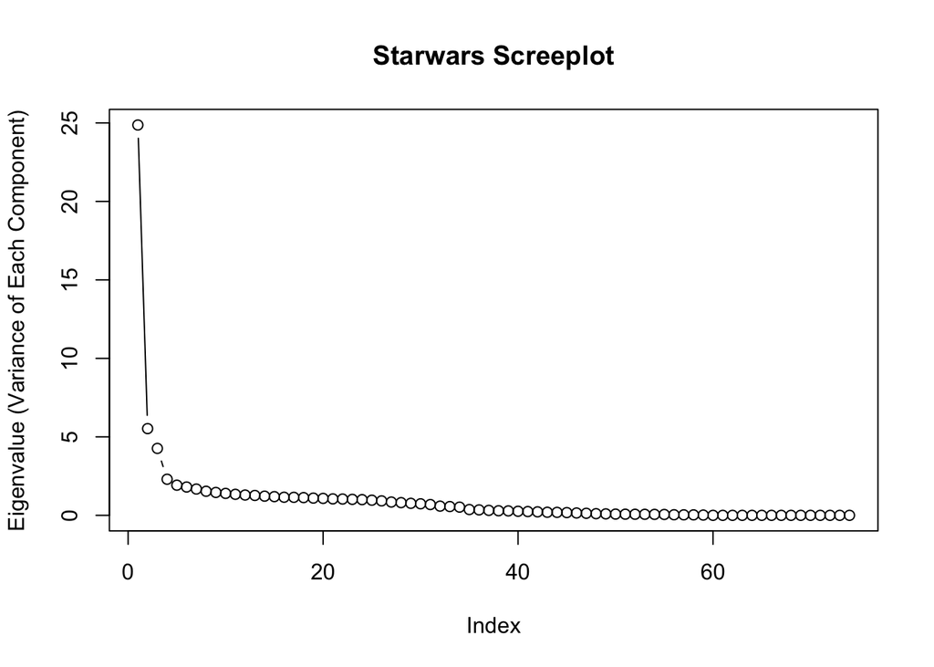

```r
plot(pca$sdev^2, type='b', ylab = 'Eigenvalue (Variance of Each Component)', main = 'Starwars Screeplot')
```

### Projection of data in 2 dimensions:

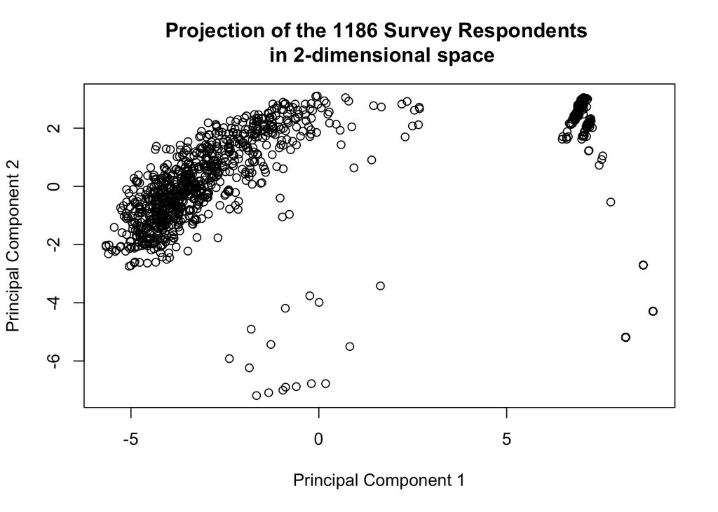

```r
plot(pca$x[,1:2], xlab = "Principal Component 1", ylab = "Principal Component 2", main='Projection of the 1186 Survey Respondents \n in 2-dimensional space')
```

It is common for points to have the same or very similar scores along PCs, particularly when each variable has a limited range of values (i.e. binary or likert scale). This means that many points can be overlapping on a plot and that can be misleading. A common solution is to “jitter” the plot which merely adds some random error to the placement of the points so that you can see overlapping groups of points with more clarity:

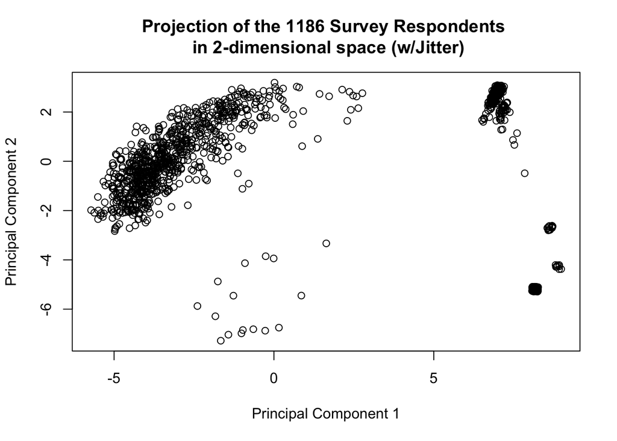

```r
plot(jitter(pca$x[,1:2],amount=0.1), xlab = "Principal Component 1", ylab = "Principal Component 2", main='Projection of the 1186 Survey Respondents \n in 2-dimensional space (w/Jitter)')
```

Note the clusters of individuals outstanding on PC1. Let’s investigate the dominant variables driving PC1. We’ll simply look at the loadings of variables on PC1, ordered by the absolute value of their magnitude (the largest will be last by default - so here I’ve printed out the top 10).

```r
tail(pca$rotation[order(abs(pca$rotation[,1])),1],10)
```

```
##                       ViewC3P0               ViewObiWanKenobi
##                     -0.1840787                     -0.1873507
##                       ViewYoda                       ViewR2D2
##                     -0.1888073                     -0.1889610
##         ViewPrincessLeiaOrgana              ViewLukeSkywalker
##                     -0.1901918                     -0.1904492
##                    ViewHanSolo      WhichCharacterShotFirstNA
##                     -0.1908215                      0.1920700
## FamiliarWithExpandedUniverseNA                   AreYouAFanNA
##                      0.1920700                      0.1936650
```

Component1 appears to picks off people who are not fans or have never seen the movies or otherwise provided trash data (lots of missing values, contradictions, etc).

```r
look = starwars[pca$x[,1]>5, ]
```

Lets subset the data according to this and rerun the analysis

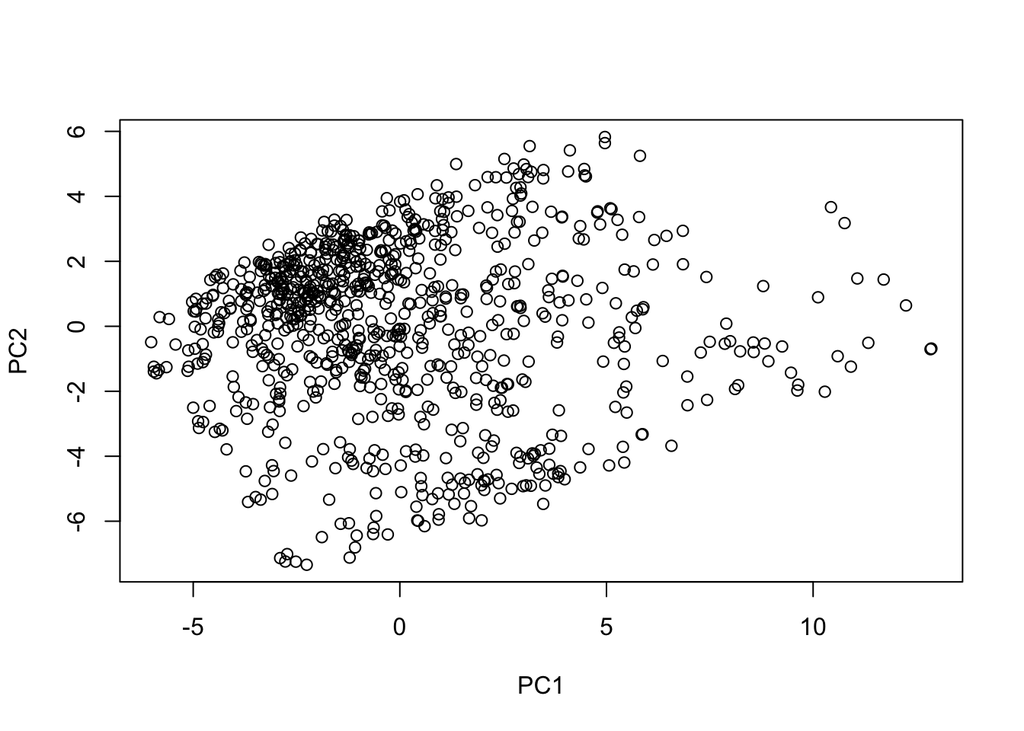

```r
subset = starwars.x[pca$x[,1]<4,]
pca = prcomp(subset)
plot(pca$x[,1:2])
```

Let’s take a look at the biplot to see if we can find anything to note about the survey responses.

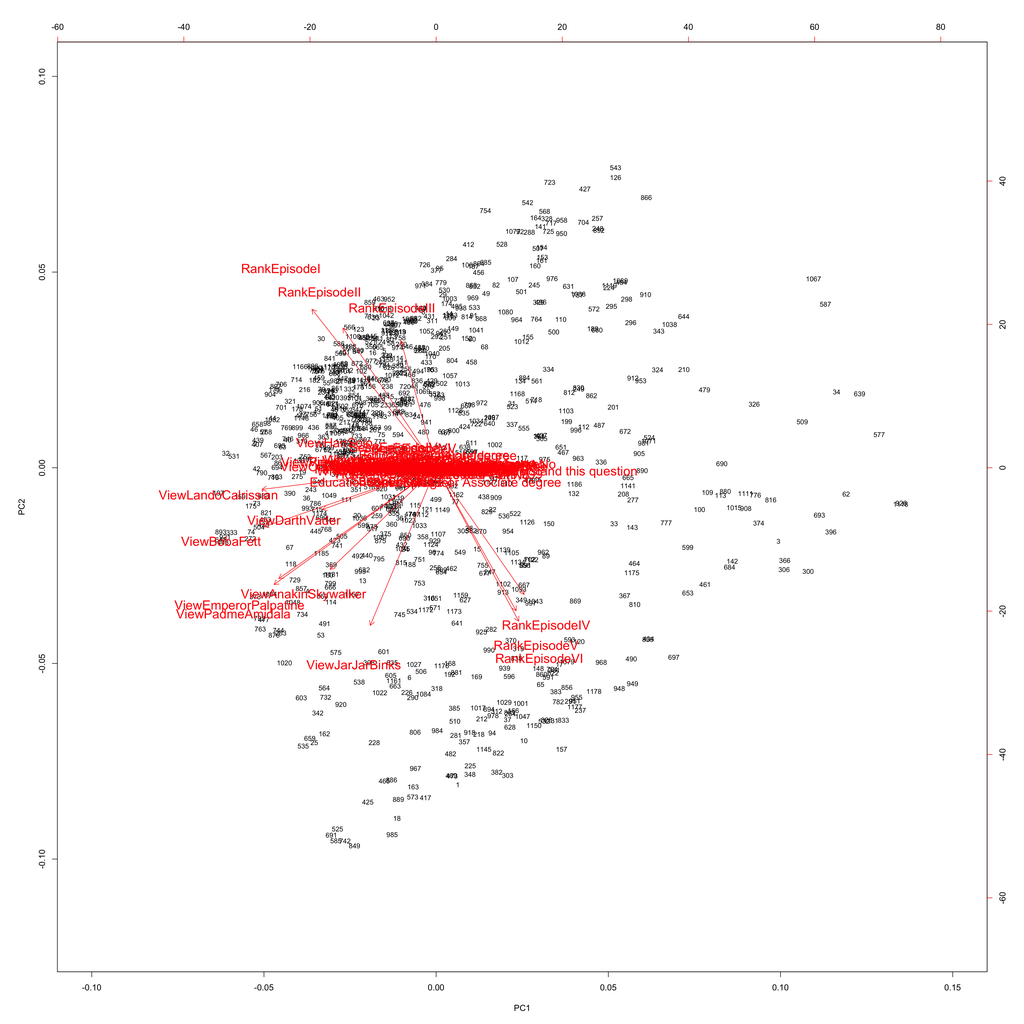

```r
biplot(pca, xlim = c(-.1,.15),ylim=c(-.12,.1),cex = c(.8, 1.5))
```